# p8106_hw4

Yueyi Xu

2024-04-18

# Problem 1

```r
# Import data, clean the data, drop na values
college_data <- read.csv("College.csv")

college_data <- college_data %>%
  select(-College)

# Data Partition
set.seed(1)

# Split the dataset into training (80%) and test (20%) sets
data_split <- initial_split(college_data, prop = 0.8)

# Extract the training and test data
training_data <- training(data_split)
testing_data <- testing(data_split)
```

### (a)

Build a regression tree on the training data to predict the response. Create a plot of the tree.

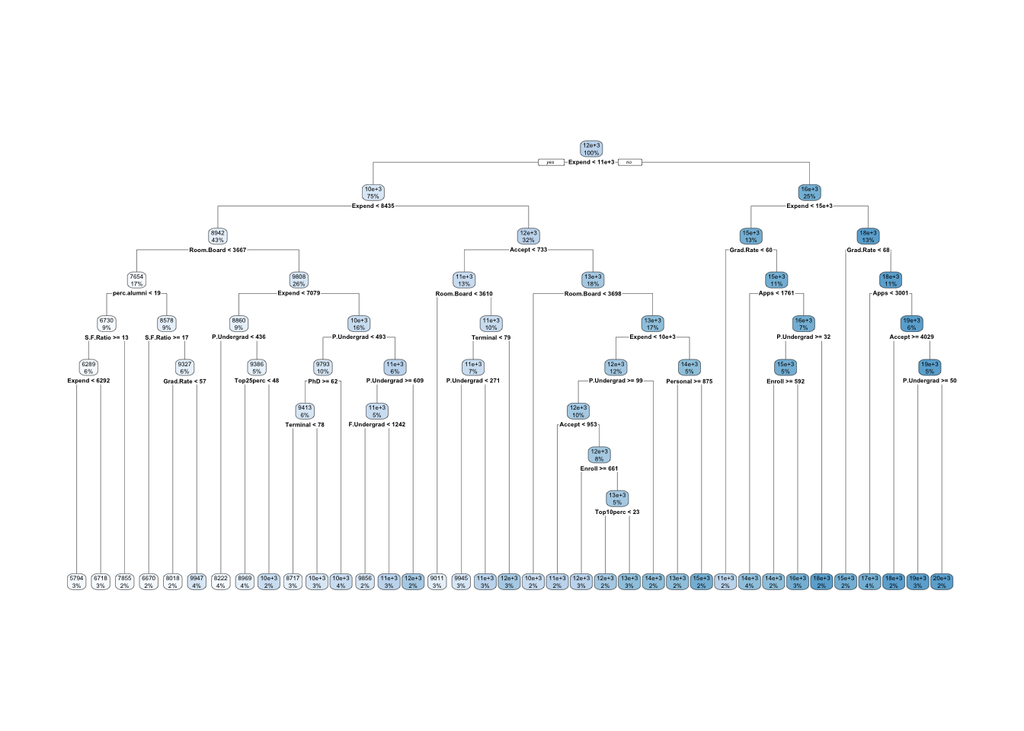

```r
set.seed(1)
tree1 <- rpart(formula = Outstate ~.,
               data = training_data,
               control = rpart.control(cp = 0))
rpart.plot(tree1)
```

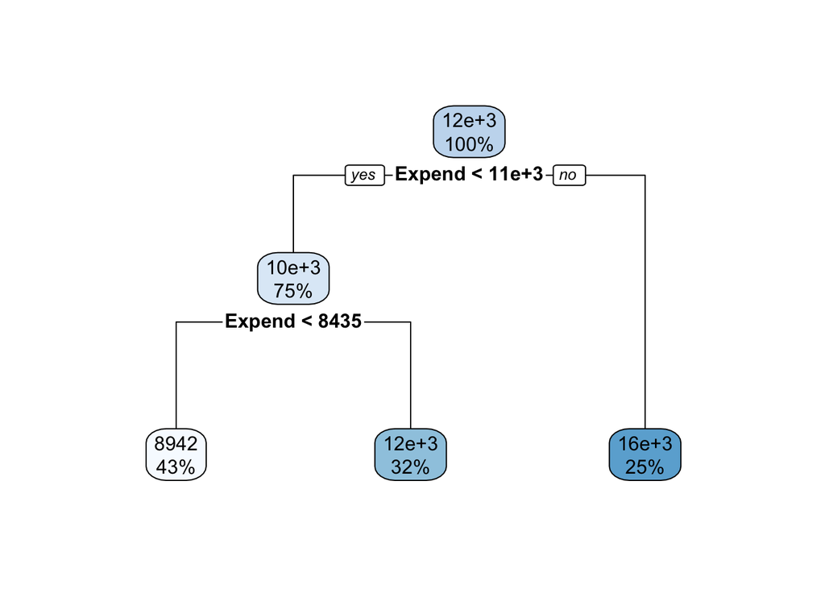

```r
set.seed(1)
tree2 <- rpart(Outstate ~.,
               data = training_data,
               control = rpart.control(cp = 0.1))
rpart.plot(tree2)
```

```r
printcp(tree1)
```

```
##
## Regression tree:
## rpart(formula = Outstate ~ ., data = training_data, control = rpart.control(cp = 0))
##
## Variables actually used in tree construction:
##  [1] Accept      Apps        Enroll      Expend      F.Undergrad Grad.Rate
##  [7] P.Undergrad perc.alumni Personal    PhD         Room.Board  S.F.Ratio
## [13] Terminal    Top10perc   Top25perc
##
## Root node error: 6.173e+09/452 = 13657034
##
## n= 452
##
##            CP nsplit rel error  xerror     xstd
## 1  0.49687912      0   1.00000 1.00379 0.061129
```

[output cut: 34 more lines]

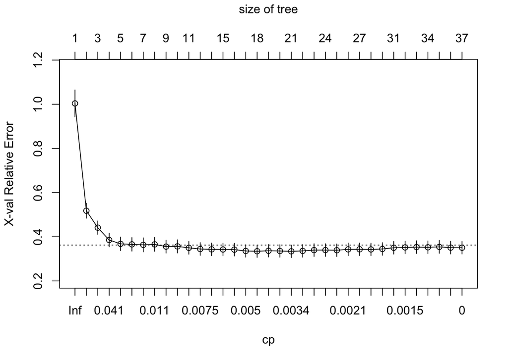

```r
cpTable <- tree1$cptable
plotcp(tree1)
```

### (b)

Perform random forest on the training data. Report the variable importance and the test error.

```r
# Perform random forest
ctrl <- trainControl(method = "cv")

rf.grid <- expand.grid(mtry = 1:16,
                       splitrule = "variance",
                       min.node.size = 1:6)

set.seed(1)
rf.fit <- train(Outstate ~.,
                data = training_data,
                method = "ranger",
                tuneGrid = rf.grid,
                trControl = ctrl,
                importance = "permutation")

# Variable Importance
df <- as.data.frame(ranger::importance(rf.fit$finalModel))
colnames(df) <- "Importance"
df %>% arrange(desc(Importance))
```

```
##             Importance
## Expend      7030634.08
## Room.Board  1621982.35
## Terminal    1160260.71
## Apps         964575.77
## Top10perc    598707.07
## PhD          578298.80
## Accept       519533.19
## Grad.Rate    460720.38
## Top25perc    457624.94
## perc.alumni  374866.11
## P.Undergrad  366030.88
## Enroll       284863.72
## S.F.Ratio    274873.52
## F.Undergrad  273363.29
## Personal     176616.87
## Books         57335.54
```

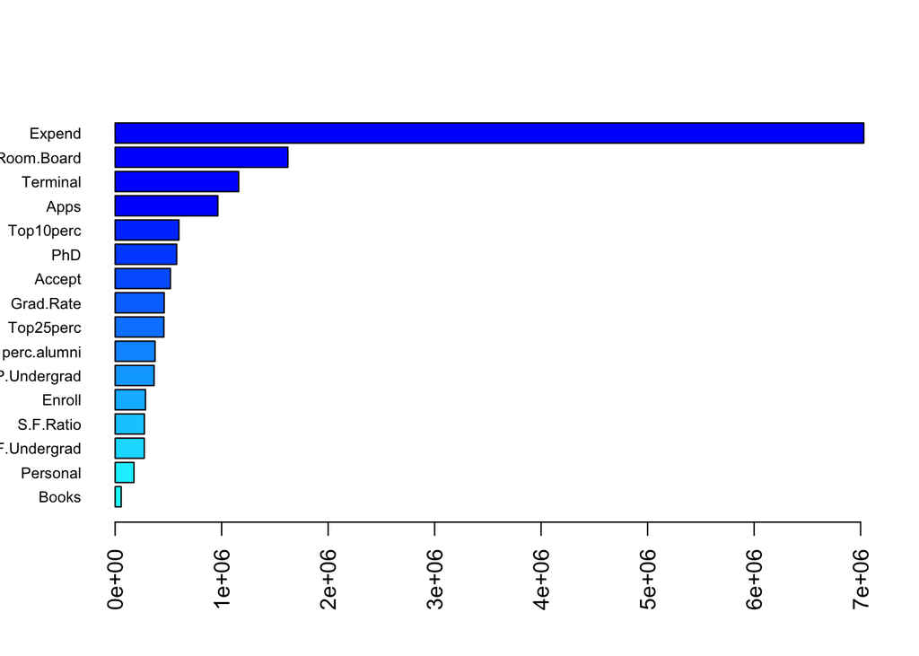

```r
importance_scores <- sort(ranger::importance(rf.fit$finalModel), decreasing = FALSE)

barplot(importance_scores,
        las = 2,
        horiz = TRUE,
        cex.names = 0.7,
        col = colorRampPalette(colors = c("cyan", "blue"))(length(importance_scores)))
```

```r
# Report test error
pred.rf <- predict(rf.fit, new_data = testing_data)
RMSE(pred.rf, testing_data$Outstate)
```

```
## [1] 5040.468
```

The variable “expend” is the most significant variable for predicting out-of-state tuition. The test error of RMSE for the random forest model is 5040.468.

### (c)

# Problem 2

```r
auto_data <- read.csv("auto.csv")

auto_data <- auto_data %>%
  mutate(mpg_cat = as.factor(mpg_cat))

set.seed(1)
data_split_auto <- initial_split(auto_data, prop = 0.7)
# Extract the training and testing data
training_data_auto <- training(data_split_auto)
testing_data_auto <- testing(data_split_auto)
```

### (a)

Build a classification tree using the training data, with mpg cat as the response. Which tree size corresponds to the lowest cross-validation error? Is this the same as the tree size obtained using the 1 SE rule?

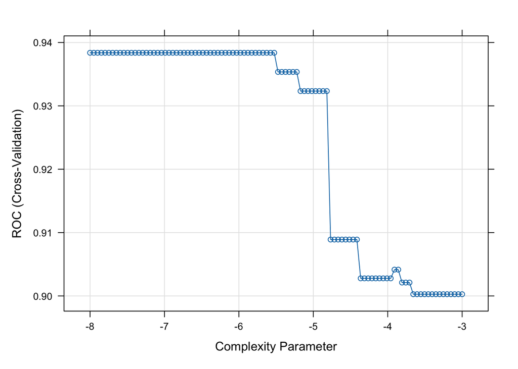

```r
ctrl_2 <- trainControl(method = "cv",
                       summaryFunction = twoClassSummary,
                       classProbs = TRUE)

ctrl_1se <- trainControl(method = "cv",
                         summaryFunction = twoClassSummary,
                         selectionFunction = "oneSE",
                         classProbs = TRUE)
set.seed(1)
rpart.fit <- train(mpg_cat ~ . ,
                   training_data_auto,
                   method = "rpart",
                   tuneGrid = data.frame(cp = exp(seq(-8,-3, len = 100))),
                   trControl = ctrl_2,
                   metric = "ROC")
plot(rpart.fit, xTrans = log)
```

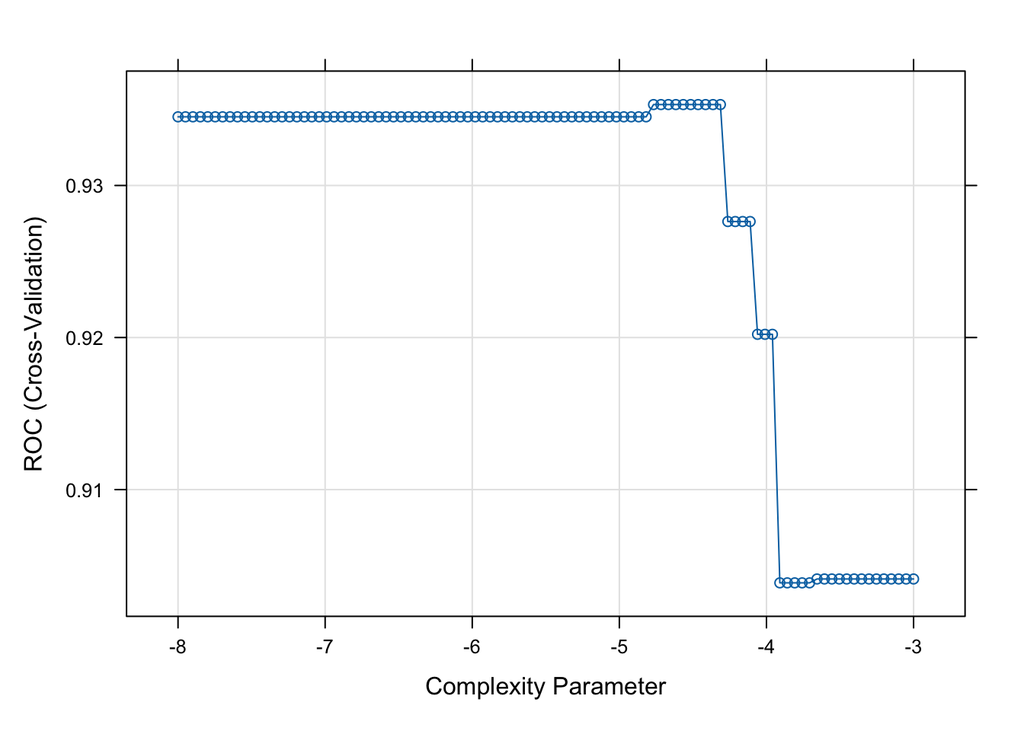

```r
rpart.fit_1se <- train(mpg_cat ~ . ,
                       training_data_auto,
                       method = "rpart",
                       tuneGrid = data.frame(cp = exp(seq(-8,-3, len = 100))),
                       trControl = ctrl_1se,
                       metric = "ROC")
plot(rpart.fit_1se, xTrans = log)
```

```r
# Displaying best cp values
cat("Best cp without 1SE rule:", rpart.fit$bestTune$cp, "\n")
```

```
## Best cp without 1SE rule: 0.003984862
```

```r
cat("Best cp with 1SE rule:", rpart.fit_1se$bestTune$cp, "\n")
```

```
## Best cp with 1SE rule: 0.01907082
```

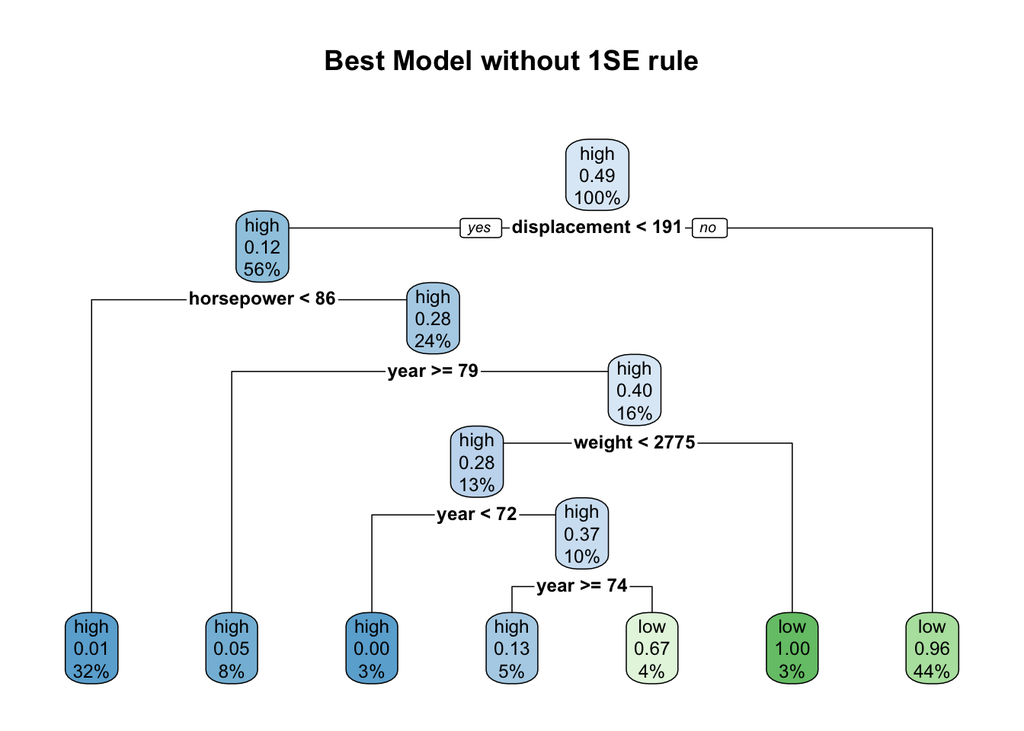

```r
# Compare trees
rpart.plot(rpart.fit$finalModel, main = "Best Model without 1SE rule")
```

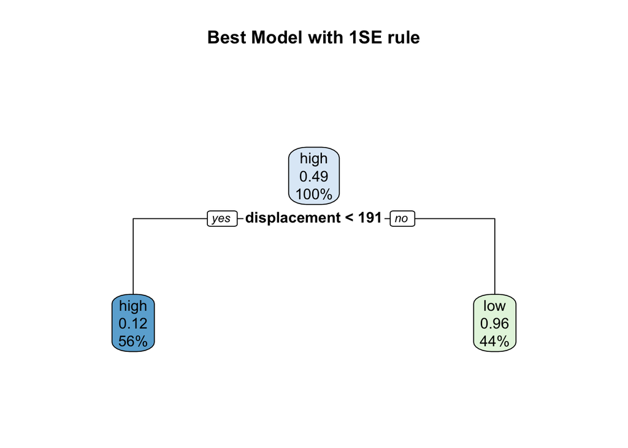

```r
rpart.plot(rpart.fit_1se$finalModel, main = "Best Model with 1SE rule")
```

The tree size corresponds to the lowest cross validation error is the one without 1SE rule with the value of 0.003984826. This tree is more complex as it has more branches. It is not the same size of the tree size using 1SE rule while the tree size with 1SE rule has the value of 0.01907082 with a simpler tree and less splits.

### (b)

Perform boosting on the training data and report the variable importance. Report the test data performance.